# Project 3: The Ames Housing Dataset

Sean Tsai, Olli Rissanen, Kit Tsang, Ying Jie Chin, Abhinav Alluri

4/17/2020

# 1. Description of the Data and our Project

The Ames Housing Dataset is an incredible dataset with 79 explanatory variables describing almost every aspect of residential homes in Ames, Iowa, a city that serves as a home for the Iowa State University and has a population of around 60,000.

The 79 variables focus on the quality and quantity of many physical attributes of the properties, and most of the variables are exactly the type of information that a typical home buyer wants to know about a potential property. There are variables about various area dimensions (such as lot size and different square footage variables), discrete variables that describe the number of items (e.g. bathrooms) occurring within the house, and categorical variables classifying e.g. streets and neighborhoods.

With the dataset and based on the listed variables, we aim to predict sale prices of different Ames, Iowa properties using different machine learning models. For our predictions, we plan to use ANN, kNN, SVR, and Random Forest models, as well as a prediction model that combines all these four models.

Besides submitting this file as our Project 3 deliverable, we will make our final predictions on a special testing dataset provided in Kaggle and use those predictions to participate in a Kaggle Competition that is based on the Ames Housing Dataset.

# 2. General Data Exploration

## Importing Train Data

```r
rawHouseData_Train <- read.csv("train.csv", stringsAsFactors = FALSE)
```

## Exploring Data

```r
str(rawHouseData_Train)
```

```
## 'data.frame':    1460 obs. of  81 variables:
##  $ Id           : int  1 2 3 4 5 6 7 8 9 10 ...
##  $ MSSubClass   : int  60 20 60 70 60 50 20 60 50 190 ...
##  $ MSZoning     : chr  "RL" "RL" "RL" "RL" ...
##  $ LotFrontage  : int  65 80 68 60 84 85 75 NA 51 50 ...
##  $ LotArea      : int  8450 9600 11250 9550 14260 14115 10084 10382 6120 7420 ...
##  $ Street       : chr  "Pave" "Pave" "Pave" "Pave" ...
##  $ Alley        : chr  NA NA NA NA ...
##  $ LotShape     : chr  "Reg" "Reg" "IR1" "IR1" ...
##  $ LandContour  : chr  "Lvl" "Lvl" "Lvl" "Lvl" ...
##  $ Utilities    : chr  "AllPub" "AllPub" "AllPub" "AllPub" ...
##  $ LotConfig    : chr  "Inside" "FR2" "Inside" "Corner" ...
##  $ LandSlope    : chr  "Gtl" "Gtl" "Gtl" "Gtl" ...
##  $ Neighborhood : chr  "CollgCr" "Veenker" "CollgCr" "Crawfor" ...
##  $ Condition1   : chr  "Norm" "Feedr" "Norm" "Norm" ...
```

[output cut: 67 more lines]

```r
summary(rawHouseData_Train)
```

```
##        Id           MSSubClass      MSZoning          LotFrontage
##  Min.   :   1.0   Min.   : 20.0   Length:1460        Min.   : 21.00
##  1st Qu.: 365.8   1st Qu.: 20.0   Class :character   1st Qu.: 59.00
##  Median : 730.5   Median : 50.0   Mode  :character   Median : 69.00
##  Mean   : 730.5   Mean   : 56.9                      Mean   : 70.05
##  3rd Qu.:1095.2   3rd Qu.: 70.0                      3rd Qu.: 80.00
##  Max.   :1460.0   Max.   :190.0                      Max.   :313.00
##                                                      NA's   :259
##     LotArea          Street             Alley             LotShape
##  Min.   :  1300   Length:1460        Length:1460        Length:1460
##  1st Qu.:  7554   Class :character   Class :character   Class :character
##  Median :  9478   Mode  :character   Mode  :character   Mode  :character
##  Mean   : 10517
##  3rd Qu.: 11602
##  Max.   :215245
##
##  LandContour         Utilities          LotConfig          LandSlope
##  Length:1460        Length:1460        Length:1460        Length:1460
##  Class :character   Class :character   Class :character   Class :character
##  Mode  :character   Mode  :character   Mode  :character   Mode  :character
##
##
##
##
##  Neighborhood        Condition1         Condition2          BldgType
##  Length:1460        Length:1460        Length:1460        Length:1460
##  Class :character   Class :character   Class :character   Class :character
##  Mode  :character   Mode  :character   Mode  :character   Mode  :character
##
##
##
##
##   HouseStyle         OverallQual      OverallCond      YearBuilt
##  Length:1460        Min.   : 1.000   Min.   :1.000   Min.   :1872
##  Class :character   1st Qu.: 5.000   1st Qu.:5.000   1st Qu.:1954
##  Mode  :character   Median : 6.000   Median :5.000   Median :1973
##                     Mean   : 6.099   Mean   :5.575   Mean   :1971
##                     3rd Qu.: 7.000   3rd Qu.:6.000   3rd Qu.:2000
##                     Max.   :10.000   Max.   :9.000   Max.   :2010
##
```

[output cut: 113 more lines]

```
##  Min.   : 1.000   Min.   :2006   Length:1460        Length:1460
##  1st Qu.: 5.000   1st Qu.:2007   Class :character   Class :character
##  Median : 6.000   Median :2008   Mode  :character   Mode  :character
##  Mean   : 6.322   Mean   :2008
##  3rd Qu.: 8.000   3rd Qu.:2009
##  Max.   :12.000   Max.   :2010
##
##    SalePrice
##  Min.   : 34900
##  1st Qu.:129975
##  Median :163000
##  Mean   :180921
##  3rd Qu.:214000
##  Max.   :755000
##
```

# 3. Data Cleaning

## Converting Data into Characters for Data Cleaning

```r
# We need to use characters for our Boruta Screening of features
CharCategory <- c(names(Filter(is.character, rawHouseData_Train)), "MSSubClass")
```

## Identifying NAs with mice

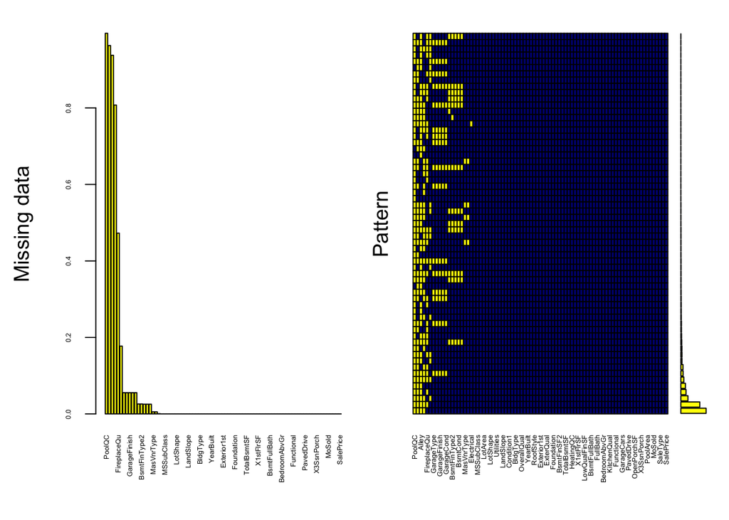

```
##
##  Variables sorted by number of missings:
##       Variable        Count
##         PoolQC 0.9952054795
##    MiscFeature 0.9630136986
##          Alley 0.9376712329
##          Fence 0.8075342466
##    FireplaceQu 0.4726027397
##    LotFrontage 0.1773972603
##     GarageType 0.0554794521
##    GarageYrBlt 0.0554794521
##   GarageFinish 0.0554794521
##     GarageQual 0.0554794521
##     GarageCond 0.0554794521
##   BsmtExposure 0.0260273973
##   BsmtFinType2 0.0260273973
##       BsmtQual 0.0253424658
##       BsmtCond 0.0253424658
##   BsmtFinType1 0.0253424658
##     MasVnrType 0.0054794521
##     MasVnrArea 0.0054794521
##     Electrical 0.0006849315
##             Id 0.0000000000
##     MSSubClass 0.0000000000
##       MSZoning 0.0000000000
##        LotArea 0.0000000000
##         Street 0.0000000000
##       LotShape 0.0000000000
##    LandContour 0.0000000000
##      Utilities 0.0000000000
##      LotConfig 0.0000000000
##      LandSlope 0.0000000000
##   Neighborhood 0.0000000000
##     Condition1 0.0000000000
##     Condition2 0.0000000000
##       BldgType 0.0000000000
##     HouseStyle 0.0000000000
##    OverallQual 0.0000000000
##    OverallCond 0.0000000000
##      YearBuilt 0.0000000000
```

[output cut: 29 more lines]

```
##     GarageCars 0.0000000000
##     GarageArea 0.0000000000
##     PavedDrive 0.0000000000
##     WoodDeckSF 0.0000000000
##    OpenPorchSF 0.0000000000
##  EnclosedPorch 0.0000000000
##     X3SsnPorch 0.0000000000
##    ScreenPorch 0.0000000000
##       PoolArea 0.0000000000
##        MiscVal 0.0000000000
##         MoSold 0.0000000000
##         YrSold 0.0000000000
##       SaleType 0.0000000000
##  SaleCondition 0.0000000000
##      SalePrice 0.0000000000
```

```r
# Importing the required libraries
library(VIM)
library(mice)

# Identifying the percentage of NAs in each column
mice_plot <- aggr(rawHouseData_Train, col=c('navyblue','yellow'),
                    numbers=TRUE, sortVars=TRUE,
                    labels=names(rawHouseData_Train), cex.axis=.4,
                    gap=3, ylab=c("Missing data","Pattern"))
```

## Removing and Imputing NAs

```r
# Dropping the row with NA in Electrical column (only one missing observation for the variable)
rawHouseData_Train <- rawHouseData_Train[!is.na(rawHouseData_Train$Electrical),]

# Dropping the GarageYrBlt column, as NAs refer to garage not built, imputing NAs with year = 0 might affect regression and other garage variables exist. Since other garage variables exist, dropping this column has no significant effect.
rawHouseData_Train <- rawHouseData_Train[,!names(rawHouseData_Train)=="GarageYrBlt"]

# Imputing NAs in MasVnrArea with 0
rawHouseData_Train$MasVnrArea <- ifelse(is.na(rawHouseData_Train$MasVnrArea) == TRUE, 0, rawHouseData_Train$MasVnrArea)

# Imputing NAs by "Missing" for characters for the rest of the columns (i.e. e.g. PoolQC, MiscFeature, Alley), where NA means that attribute does not exist
for(i in CharCategory){
  rawHouseData_Train[,i] = ifelse(is.na(rawHouseData_Train[,i]), "Missing", rawHouseData_Train[,i])
}

# Imputing the NAs for Lot Frontage using predictive mean matching
rawHouseData_Train <- mice(rawHouseData_Train, m=5, maxit = 50, method = 'pmm', seed = 100)
rawHouseData_Train <- mice::complete(rawHouseData_Train)
```

## Further Cleaning with Boruta Training

```r
# Boruta Train package to identify important features (https://www.datacamp.com/community/tutorials/feature-selection-R-boruta)

# Importing the required library
library(Boruta)

# Executing Boruta Training
set.seed(233)
boruta_Train <- Boruta(rawHouseData_Train[names(rawHouseData_Train) != "Id" & names(rawHouseData_Train) != "SalePrice" ], rawHouseData_Train$SalePrice ,  doTrace = 2)
final.boruta <- TentativeRoughFix(boruta_Train)
```

## A Look into the Boruta Results

```r
print(final.boruta)
```

```
## Boruta performed 99 iterations in 5.658693 mins.
## Tentatives roughfixed over the last 99 iterations.
##  55 attributes confirmed important: BedroomAbvGr, BldgType, BsmtCond,
## BsmtFinSF1, BsmtFinType1 and 50 more;
##  23 attributes confirmed unimportant: Alley, BsmtExposure, BsmtFinSF2,
## BsmtFinType2, BsmtHalfBath and 18 more;
```

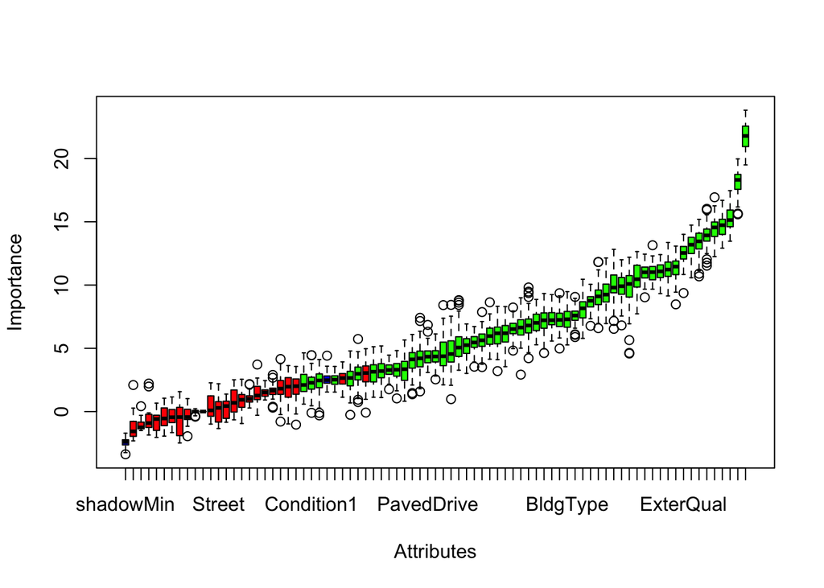

```r
plot(final.boruta)
```

```r
# Selecting only the features that passed the Boruta Screening
cleanHouseData_Train <- rawHouseData_Train[getSelectedAttributes(final.boruta, withTentative = F)]

# Converting characters back into factors
cleanHouseData_Train[sapply(cleanHouseData_Train,is.character)] <- lapply(cleanHouseData_Train[sapply(cleanHouseData_Train,is.character)], as.factor)

# Adding SalePrice back into the train data
cleanHouseData_Train$SalePrice <- rawHouseData_Train$SalePrice
```

## A Look into the cleaned data

```r
str(cleanHouseData_Train)
```

```
## 'data.frame':    1459 obs. of  56 variables:
##  $ MSSubClass   : int  60 20 60 70 60 50 20 60 50 190 ...
##  $ MSZoning     : Factor w/ 5 levels "C (all)","FV",..: 4 4 4 4 4 4 4 4 5 4 ...
##  $ LotFrontage  : int  65 80 68 60 84 85 75 87 51 50 ...
##  $ LotArea      : int  8450 9600 11250 9550 14260 14115 10084 10382 6120 7420 ...
##  $ LotShape     : Factor w/ 4 levels "IR1","IR2","IR3",..: 4 4 1 1 1 1 4 1 4 4 ...
##  $ LandContour  : Factor w/ 4 levels "Bnk","HLS","Low",..: 4 4 4 4 4 4 4 4 4 4 ...
##  $ LandSlope    : Factor w/ 3 levels "Gtl","Mod","Sev": 1 1 1 1 1 1 1 1 1 1 ...
##  $ Neighborhood : Factor w/ 25 levels "Blmngtn","Blueste",..: 6 25 6 7 14 12 21 17 18 4 ...
##  $ Condition1   : Factor w/ 9 levels "Artery","Feedr",..: 3 2 3 3 3 3 3 5 1 1 ...
##  $ BldgType     : Factor w/ 5 levels "1Fam","2fmCon",..: 1 1 1 1 1 1 1 1 1 2 ...
##  $ HouseStyle   : Factor w/ 8 levels "1.5Fin","1.5Unf",..: 6 3 6 6 6 1 3 6 1 2 ...
##  $ OverallQual  : int  7 6 7 7 8 5 8 7 7 5 ...
##  $ OverallCond  : int  5 8 5 5 5 5 5 6 5 6 ...
##  $ YearBuilt    : int  2003 1976 2001 1915 2000 1993 2004 1973 1931 1939 ...
```

[output cut: 42 more lines]

```r
summary(cleanHouseData_Train)
```

```
##    MSSubClass        MSZoning     LotFrontage        LotArea       LotShape
##  Min.   : 20.00   C (all):  10   Min.   : 21.00   Min.   :  1300   IR1:484
##  1st Qu.: 20.00   FV     :  65   1st Qu.: 53.00   1st Qu.:  7549   IR2: 41
##  Median : 50.00   RH     :  16   Median : 66.00   Median :  9477   IR3: 10
##  Mean   : 56.88   RL     :1150   Mean   : 67.67   Mean   : 10517   Reg:924
##  3rd Qu.: 70.00   RM     : 218   3rd Qu.: 80.00   3rd Qu.: 11603
##  Max.   :190.00                  Max.   :313.00   Max.   :215245
##
##  LandContour LandSlope   Neighborhood   Condition1     BldgType
##  Bnk:  63    Gtl:1381   NAmes  :225   Norm   :1259   1Fam  :1219
##  HLS:  50    Mod:  65   CollgCr:150   Feedr  :  81   2fmCon:  31
##  Low:  36    Sev:  13   OldTown:113   Artery :  48   Duplex:  52
##  Lvl:1310               Edwards:100   RRAn   :  26   Twnhs :  43
##                         Somerst: 86   PosN   :  19   TwnhsE: 114
##                         Gilbert: 79   RRAe   :  11
##                         (Other):706   (Other):  15
##    HouseStyle   OverallQual    OverallCond      YearBuilt     YearRemodAdd
##  1Story :726   Min.   : 1.0   Min.   :1.000   Min.   :1872   Min.   :1950
##  2Story :445   1st Qu.: 5.0   1st Qu.:5.000   1st Qu.:1954   1st Qu.:1967
##  1.5Fin :154   Median : 6.0   Median :5.000   Median :1973   Median :1994
##  SLvl   : 64   Mean   : 6.1   Mean   :5.576   Mean   :1971   Mean   :1985
##  SFoyer : 37   3rd Qu.: 7.0   3rd Qu.:6.000   3rd Qu.:2000   3rd Qu.:2004
##  1.5Unf : 14   Max.   :10.0   Max.   :9.000   Max.   :2010   Max.   :2010
##  (Other): 19
##    RoofStyle     Exterior1st   Exterior2nd    MasVnrType    MasVnrArea
##  Flat   :  13   VinylSd:514   VinylSd:503   BrkCmn : 15   Min.   :   0.0
##  Gable  :1140   HdBoard:222   MetalSd:214   BrkFace:445   1st Qu.:   0.0
##  Gambrel:  11   MetalSd:220   HdBoard:207   Missing:  8   Median :   0.0
##  Hip    : 286   Wd Sdng:206   Wd Sdng:197   None   :863   Mean   : 103.2
##  Mansard:   7   Plywood:108   Plywood:142   Stone  :128   3rd Qu.: 164.5
##  Shed   :   2   CemntBd: 61   CmentBd: 60                 Max.   :1600.0
##                 (Other):128   (Other):136
##  ExterQual  Foundation     BsmtQual      BsmtCond     BsmtFinType1
##  Ex: 52    BrkTil:146   Ex     :121   Fa     :  45   ALQ    :220
##  Fa: 14    CBlock:634   Fa     : 35   Gd     :  65   BLQ    :148
##  Gd:488    PConc :646   Gd     :617   Missing:  37   GLQ    :418
##  TA:905    Slab  : 24   Missing: 37   Po     :   2   LwQ    : 74
##            Stone :  6   TA     :649   TA     :1310   Missing: 37
##            Wood  :  3                                Rec    :133
##                                                      Unf    :429
```

[output cut: 41 more lines]

```
##  N:  90     Min.   :  0.00   Min.   :  0.00   GdPrv  :  59   Abnorml: 101
##  P:  30     1st Qu.:  0.00   1st Qu.:  0.00   GdWo   :  54   AdjLand:   4
##  Y:1339     Median :  0.00   Median : 25.00   Missing:1178   Alloca :  12
##             Mean   : 94.24   Mean   : 46.69   MnPrv  : 157   Family :  20
##             3rd Qu.:168.00   3rd Qu.: 68.00   MnWw   :  11   Normal :1197
##             Max.   :857.00   Max.   :547.00                  Partial: 125
##
##    SalePrice
##  Min.   : 34900
##  1st Qu.:129950
##  Median :163000
##  Mean   :180930
##  3rd Qu.:214000
##  Max.   :755000
##
```

# 4. Linear and Stepwise Regressions

In this section, we conduct Linear and Stepwise Regressions to explore variable signifigance.

## Building a Linear Regression

```r
SalePrice_LinReg = lm(SalePrice ~ ., data = cleanHouseData_Train)
```

### Summary of Linear Regression Performance

```r
summary(SalePrice_LinReg)
```

```
##
## Call:
## lm(formula = SalePrice ~ ., data = cleanHouseData_Train)
##
## Residuals:
##     Min      1Q  Median      3Q     Max
## -315937  -10972       0   10003  205526
##
## Coefficients: (6 not defined because of singularities)
##                        Estimate Std. Error t value Pr(>|t|)
## (Intercept)          -4.494e+05  2.042e+05  -2.201 0.027938 *
## MSSubClass           -5.270e+01  9.735e+01  -0.541 0.588354
## MSZoningFV            3.846e+04  1.427e+04   2.695 0.007131 **
## MSZoningRH            3.096e+04  1.417e+04   2.184 0.029143 *
## MSZoningRL            3.307e+04  1.204e+04   2.747 0.006095 **
## MSZoningRM            3.113e+04  1.126e+04   2.765 0.005780 **
## LotFrontage          -1.170e+02  3.971e+01  -2.947 0.003263 **
## LotArea               6.807e-01  1.249e-01   5.449 6.06e-08 ***
## LotShapeIR2           4.473e+03  5.053e+03   0.885 0.376192
## LotShapeIR3          -2.745e+04  1.046e+04  -2.625 0.008780 **
## LotShapeReg           9.542e+01  1.871e+03   0.051 0.959329
## LandContourHLS        2.579e+04  6.142e+03   4.199 2.86e-05 ***
## LandContourLow        1.917e+04  7.587e+03   2.527 0.011636 *
## LandContourLvl        1.909e+04  4.413e+03   4.326 1.64e-05 ***
## LandSlopeMod          1.142e+04  4.733e+03   2.413 0.015983 *
## LandSlopeSev         -2.463e+04  1.229e+04  -2.003 0.045374 *
## NeighborhoodBlueste  -7.996e+03  2.315e+04  -0.345 0.729844
## NeighborhoodBrDale    2.571e+03  1.334e+04   0.193 0.847132
## NeighborhoodBrkSide  -5.034e+03  1.127e+04  -0.446 0.655339
## NeighborhoodClearCr  -9.117e+03  1.117e+04  -0.816 0.414541
## NeighborhoodCollgCr  -4.667e+03  8.845e+03  -0.528 0.597791
## NeighborhoodCrawfor   1.267e+04  1.032e+04   1.227 0.219920
## NeighborhoodEdwards  -2.383e+04  9.713e+03  -2.453 0.014303 *
## NeighborhoodGilbert  -1.214e+04  9.341e+03  -1.300 0.193815
## NeighborhoodIDOTRR   -1.232e+04  1.290e+04  -0.956 0.339449
## NeighborhoodMeadowV  -3.544e+03  1.352e+04  -0.262 0.793200
## NeighborhoodMitchel  -2.287e+04  9.883e+03  -2.314 0.020804 *
## NeighborhoodNAmes    -1.461e+04  9.507e+03  -1.537 0.124585
## NeighborhoodNoRidge   4.095e+04  1.020e+04   4.015 6.28e-05 ***
## NeighborhoodNPkVill   3.963e+03  1.714e+04   0.231 0.817162
```

[output cut: 155 more lines]

```
## FenceGdWo             1.050e+03  5.851e+03   0.180 0.857551
## FenceMissing          3.067e+03  4.340e+03   0.707 0.479821
## FenceMnPrv            5.888e+03  4.778e+03   1.232 0.218128
## FenceMnWw            -2.503e+03  9.977e+03  -0.251 0.801920
## SaleConditionAdjLand -9.307e+02  1.746e+04  -0.053 0.957496
## SaleConditionAlloca   7.394e+03  1.019e+04   0.725 0.468343
## SaleConditionFamily   2.025e+03  7.308e+03   0.277 0.781794
## SaleConditionNormal   4.140e+03  3.267e+03   1.267 0.205380
## SaleConditionPartial  1.403e+04  4.596e+03   3.053 0.002312 **
## ---
## Signif. codes:  0 '***' 0.001 '**' 0.01 '*' 0.05 '.' 0.1 ' ' 1
##
## Residual standard error: 28050 on 1271 degrees of freedom
## Multiple R-squared:  0.8914, Adjusted R-squared:  0.8754
## F-statistic:  55.8 on 187 and 1271 DF,  p-value: < 2.2e-16
```

## Building a Stepwise Regression

```r
# Importing the required library
library(MASS)

# Creating the regression
SalePrice_StepReg = stepAIC(SalePrice_LinReg, direction = "both", trace = FALSE)
```

### Summary of the Stepwise Regression Performance

```r
summary(SalePrice_StepReg)
```

```
##
## Call:
## lm(formula = SalePrice ~ MSZoning + LotFrontage + LotArea + LotShape +
##     LandContour + LandSlope + Neighborhood + Condition1 + BldgType +
##     HouseStyle + OverallQual + OverallCond + YearBuilt + Exterior1st +
##     MasVnrArea + ExterQual + BsmtQual + BsmtFinType1 + X2ndFlrSF +
##     GrLivArea + BsmtFullBath + FullBath + BedroomAbvGr + KitchenAbvGr +
##     KitchenQual + TotRmsAbvGrd + Functional + Fireplaces + GarageCars +
##     GarageQual + GarageCond + WoodDeckSF + SaleCondition, data = cleanHouseData_Train)
##
## Residuals:
##     Min      1Q  Median      3Q     Max
## -317180  -11157    -220   10559  234598
##
## Coefficients: (2 not defined because of singularities)
##                        Estimate Std. Error t value Pr(>|t|)
## (Intercept)          -4.486e+05  1.482e+05  -3.027 0.002513 **
## MSZoningFV            3.644e+04  1.359e+04   2.682 0.007406 **
## MSZoningRH            2.717e+04  1.368e+04   1.987 0.047181 *
## MSZoningRL            3.150e+04  1.148e+04   2.745 0.006135 **
## MSZoningRM            2.882e+04  1.072e+04   2.689 0.007251 **
## LotFrontage          -9.853e+01  3.783e+01  -2.605 0.009301 **
## LotArea               5.840e-01  1.148e-01   5.088 4.12e-07 ***
## LotShapeIR2           4.317e+03  4.903e+03   0.881 0.378722
## LotShapeIR3          -2.516e+04  9.779e+03  -2.573 0.010183 *
## LotShapeReg          -3.863e+01  1.815e+03  -0.021 0.983021
## LandContourHLS        2.608e+04  5.896e+03   4.423 1.05e-05 ***
## LandContourLow        1.932e+04  7.116e+03   2.716 0.006701 **
## LandContourLvl        1.930e+04  4.260e+03   4.531 6.40e-06 ***
## LandSlopeMod          1.247e+04  4.464e+03   2.793 0.005303 **
## LandSlopeSev         -1.122e+04  1.076e+04  -1.042 0.297408
## NeighborhoodBlueste  -5.160e+03  2.216e+04  -0.233 0.815923
## NeighborhoodBrDale    8.696e+03  1.269e+04   0.685 0.493375
## NeighborhoodBrkSide  -4.891e+03  1.071e+04  -0.457 0.647999
## NeighborhoodClearCr  -3.660e+03  1.054e+04  -0.347 0.728409
## NeighborhoodCollgCr  -3.333e+03  8.446e+03  -0.395 0.693174
## NeighborhoodCrawfor   1.127e+04  9.927e+03   1.135 0.256408
## NeighborhoodEdwards  -2.058e+04  9.255e+03  -2.224 0.026333 *
## NeighborhoodGilbert  -8.857e+03  9.000e+03  -0.984 0.325250
## NeighborhoodIDOTRR   -9.565e+03  1.218e+04  -0.785 0.432532
```

[output cut: 90 more lines]

```
## GarageCondMissing            NA         NA      NA       NA
## GarageCondPo          1.407e+05  4.097e+04   3.434 0.000614 ***
## GarageCondTA          1.427e+05  3.754e+04   3.802 0.000150 ***
## WoodDeckSF            1.909e+01  6.697e+00   2.850 0.004434 **
## SaleConditionAdjLand  1.416e+04  1.532e+04   0.924 0.355683
## SaleConditionAlloca   8.000e+03  9.648e+03   0.829 0.407118
## SaleConditionFamily   2.573e+03  7.156e+03   0.359 0.719279
## SaleConditionNormal   4.647e+03  3.147e+03   1.476 0.140058
## SaleConditionPartial  1.427e+04  4.414e+03   3.234 0.001252 **
## ---
## Signif. codes:  0 '***' 0.001 '**' 0.01 '*' 0.05 '.' 0.1 ' ' 1
##
## Residual standard error: 27970 on 1338 degrees of freedom
## Multiple R-squared:  0.8863, Adjusted R-squared:  0.8761
## F-statistic: 86.95 on 120 and 1338 DF,  p-value: < 2.2e-16
```

# 5. Creating a Normalized Version of the Data

## Converting Categorical Data to Numeric Data

```r
cleanHouseData_Train[] <- data.matrix(cleanHouseData_Train)
```

## Normalization function

```r
normalize <- function(x) {
  return((x - min(x)) / (max(x) - min(x)))
}
```

## Executing the normalization

```r
# Normalizing Data (excluding SalePrice column)
Norm_HouseData <- as.data.frame(lapply(cleanHouseData_Train[,!names(cleanHouseData_Train) == "SalePrice"], normalize))

# Adding the SalePrice variable to the normalized data
Norm_HouseData$SalePrice <- cleanHouseData_Train$SalePrice
```

## A look into the Normalized Data

```r
str(Norm_HouseData)
```

```
## 'data.frame':    1459 obs. of  56 variables:
##  $ MSSubClass   : num  0.235 0 0.235 0.294 0.235 ...
##  $ MSZoning     : num  0.75 0.75 0.75 0.75 0.75 0.75 0.75 0.75 1 0.75 ...
##  $ LotFrontage  : num  0.151 0.202 0.161 0.134 0.216 ...
##  $ LotArea      : num  0.0334 0.0388 0.0465 0.0386 0.0606 ...
##  $ LotShape     : num  1 1 0 0 0 0 1 0 1 1 ...
##  $ LandContour  : num  1 1 1 1 1 1 1 1 1 1 ...
##  $ LandSlope    : num  0 0 0 0 0 0 0 0 0 0 ...
##  $ Neighborhood : num  0.208 1 0.208 0.25 0.542 ...
##  $ Condition1   : num  0.25 0.125 0.25 0.25 0.25 0.25 0.25 0.5 0 0 ...
##  $ BldgType     : num  0 0 0 0 0 0 0 0 0 0.25 ...
##  $ HouseStyle   : num  0.714 0.286 0.714 0.714 0.714 ...
##  $ OverallQual  : num  0.667 0.556 0.667 0.667 0.778 ...
##  $ OverallCond  : num  0.5 0.875 0.5 0.5 0.5 0.5 0.5 0.625 0.5 0.625 ...
##  $ YearBuilt    : num  0.949 0.754 0.935 0.312 0.928 ...
```

[output cut: 42 more lines]

```r
summary(Norm_HouseData)
```

```
##    MSSubClass        MSZoning       LotFrontage        LotArea
##  Min.   :0.0000   Min.   :0.0000   Min.   :0.0000   Min.   :0.00000
##  1st Qu.:0.0000   1st Qu.:0.7500   1st Qu.:0.1096   1st Qu.:0.02921
##  Median :0.1765   Median :0.7500   Median :0.1541   Median :0.03822
##  Mean   :0.2169   Mean   :0.7572   Mean   :0.1598   Mean   :0.04308
##  3rd Qu.:0.2941   3rd Qu.:0.7500   3rd Qu.:0.2021   3rd Qu.:0.04816
##  Max.   :1.0000   Max.   :1.0000   Max.   :1.0000   Max.   :1.00000
##     LotShape       LandContour       LandSlope        Neighborhood
##  Min.   :0.0000   Min.   :0.0000   Min.   :0.00000   Min.   :0.0000
##  1st Qu.:0.0000   1st Qu.:1.0000   1st Qu.:0.00000   1st Qu.:0.2917
##  Median :1.0000   Median :1.0000   Median :0.00000   Median :0.5000
##  Mean   :0.6472   Mean   :0.9257   Mean   :0.03119   Mean   :0.5059
##  3rd Qu.:1.0000   3rd Qu.:1.0000   3rd Qu.:0.00000   3rd Qu.:0.7083
##  Max.   :1.0000   Max.   :1.0000   Max.   :1.00000   Max.   :1.0000
##    Condition1        BldgType        HouseStyle      OverallQual
##  Min.   :0.0000   Min.   :0.0000   Min.   :0.0000   Min.   :0.0000
##  1st Qu.:0.2500   1st Qu.:0.0000   1st Qu.:0.2857   1st Qu.:0.4444
##  Median :0.2500   Median :0.0000   Median :0.2857   Median :0.5556
##  Mean   :0.2539   Mean   :0.1234   Mean   :0.4337   Mean   :0.5667
##  3rd Qu.:0.2500   3rd Qu.:0.0000   3rd Qu.:0.7143   3rd Qu.:0.6667
##  Max.   :1.0000   Max.   :1.0000   Max.   :1.0000   Max.   :1.0000
##   OverallCond      YearBuilt       YearRemodAdd      RoofStyle
##  Min.   :0.000   Min.   :0.0000   Min.   :0.0000   Min.   :0.0000
##  1st Qu.:0.500   1st Qu.:0.5942   1st Qu.:0.2833   1st Qu.:0.2000
##  Median :0.500   Median :0.7319   Median :0.7333   Median :0.2000
##  Mean   :0.572   Mean   :0.7192   Mean   :0.5808   Mean   :0.2821
##  3rd Qu.:0.625   3rd Qu.:0.9275   3rd Qu.:0.9000   3rd Qu.:0.2000
##  Max.   :1.000   Max.   :1.0000   Max.   :1.0000   Max.   :1.0000
##   Exterior1st      Exterior2nd       MasVnrType       MasVnrArea
##  Min.   :0.0000   Min.   :0.0000   Min.   :0.0000   Min.   :0.00000
##  1st Qu.:0.5714   1st Qu.:0.5333   1st Qu.:0.2500   1st Qu.:0.00000
##  Median :0.8571   Median :0.8667   Median :0.7500   Median :0.00000
##  Mean   :0.6874   Mean   :0.6892   Mean   :0.6103   Mean   :0.06449
##  3rd Qu.:0.8571   3rd Qu.:0.8667   3rd Qu.:0.7500   3rd Qu.:0.10281
##  Max.   :1.0000   Max.   :1.0000   Max.   :1.0000   Max.   :1.00000
##    ExterQual        Foundation        BsmtQual         BsmtCond
##  Min.   :0.0000   Min.   :0.0000   Min.   :0.0000   Min.   :0.0000
##  1st Qu.:0.6667   1st Qu.:0.2000   1st Qu.:0.5000   1st Qu.:1.0000
##  Median :1.0000   Median :0.2000   Median :0.5000   Median :1.0000
##  Mean   :0.8465   Mean   :0.2792   Mean   :0.6813   Mean   :0.9227
```

[output cut: 43 more lines]

```
##  Max.   :1.0000   Max.   :1.0000   Max.   :1.0000   Max.   :1.0000
##    GarageQual       GarageCond       PavedDrive      WoodDeckSF
##  Min.   :0.0000   Min.   :0.0000   Min.   :0.000   Min.   :0.000
##  1st Qu.:1.0000   1st Qu.:1.0000   1st Qu.:1.000   1st Qu.:0.000
##  Median :1.0000   Median :1.0000   Median :1.000   Median :0.000
##  Mean   :0.9432   Mean   :0.9526   Mean   :0.928   Mean   :0.110
##  3rd Qu.:1.0000   3rd Qu.:1.0000   3rd Qu.:1.000   3rd Qu.:0.196
##  Max.   :1.0000   Max.   :1.0000   Max.   :1.000   Max.   :1.000
##   OpenPorchSF          Fence        SaleCondition      SalePrice
##  Min.   :0.00000   Min.   :0.0000   Min.   :0.0000   Min.   : 34900
##  1st Qu.:0.00000   1st Qu.:0.5000   1st Qu.:0.8000   1st Qu.:129950
##  Median :0.04570   Median :0.5000   Median :0.8000   Median :163000
##  Mean   :0.08536   Mean   :0.5012   Mean   :0.7541   Mean   :180930
##  3rd Qu.:0.12431   3rd Qu.:0.5000   3rd Qu.:0.8000   3rd Qu.:214000
##  Max.   :1.00000   Max.   :1.0000   Max.   :1.0000   Max.   :755000
```

# 6. Dividing Data into Train and Test parts

## Randomizing Data and Creating Train and Test IDs

```r
set.seed(300)
trainID <- sample(1:nrow(cleanHouseData_Train),0.8*nrow(cleanHouseData_Train))
testID <- setdiff(1:nrow(cleanHouseData_Train), trainID)
```

## Dividing the Original Cleaned Data into Train and Test parts

Here we divide the original cleaned data (i.e. cleanHouseData_Train) to Train and Test parts to be used in our Random Forest and SVR Models.

```r
OG_HouseData_Train <- cleanHouseData_Train[trainID,]
OG_HouseData_Test <- cleanHouseData_Train[testID,]
```

## Dividing the Normalized Data into Train and Test parts

Here we divide the normalized data into Train and Test parts to be used in our ANN and kNN Models.

```r
Norm_HouseData_Train <- Norm_HouseData[trainID,]
Norm_HouseData_Test <- Norm_HouseData[testID,]
```

# 7. Individual Predictive Models

## Random Forest Model

### Importing the required libraries

```r
library(caret)
library(randomForest)
```

### Renaming Train and Test Data for Clarity

```r
RF_HouseData_Train <- OG_HouseData_Train
RF_HouseData_Test <- OG_HouseData_Test
```

### Creating the Random Forest Model

To decide the variable combination to use in the Random Forest Model, we tested 2 different variable combinations. The first combination of variables included all variables in RF_HouseData_Train, which includes all the variables deemed as important by Boruta. The second combination of variables included all the significant variables with a p-value lower than 0.05 from the final Stepwise Regression. We used the significant variables from the final Stepwise Regression instead of the significant variables from our first Linear Regression because the Stepwise Regression was more optimimized with a lower AIC.

Using only the significant variables from the Stepwise Regression produced the better accuracy out of the two options (measured by the strength of correlation between the predicted house prices and the actual house prices listed in the test part of the data) and, thus that combination of variables is chosen for our Random Forest Model.

```r
set.seed(300)
RF_Model <- randomForest(SalePrice ~ MSZoning + LotFrontage + LotArea + LotShape +
    LandContour + LandSlope + Neighborhood + Condition1 + BldgType +
    HouseStyle + OverallQual + OverallCond + YearBuilt + Exterior1st +
    MasVnrArea + ExterQual + BsmtQual + BsmtFinType1 + X2ndFlrSF +
    GrLivArea + BsmtFullBath + FullBath + BedroomAbvGr + KitchenAbvGr +
    KitchenQual + TotRmsAbvGrd + Functional + Fireplaces + GarageCars +
    GarageQual + GarageCond + WoodDeckSF + SaleCondition, data = RF_HouseData_Train)

# Basic information about the model
RF_Model
```

```
##
## Call:
##  randomForest(formula = SalePrice ~ MSZoning + LotFrontage + LotArea +      LotShape + LandContour + LandSlope + Neighborhood + Condition1 +      BldgType + HouseStyle + OverallQual + OverallCond + YearBuilt +      Exterior1st + MasVnrArea + ExterQual + BsmtQual + BsmtFinType1 +      X2ndFlrSF + …
##                Type of random forest: regression
##                      Number of trees: 500
## No. of variables tried at each split: 11
##
##           Mean of squared residuals: 887762130
##                     % Var explained: 85.87
```

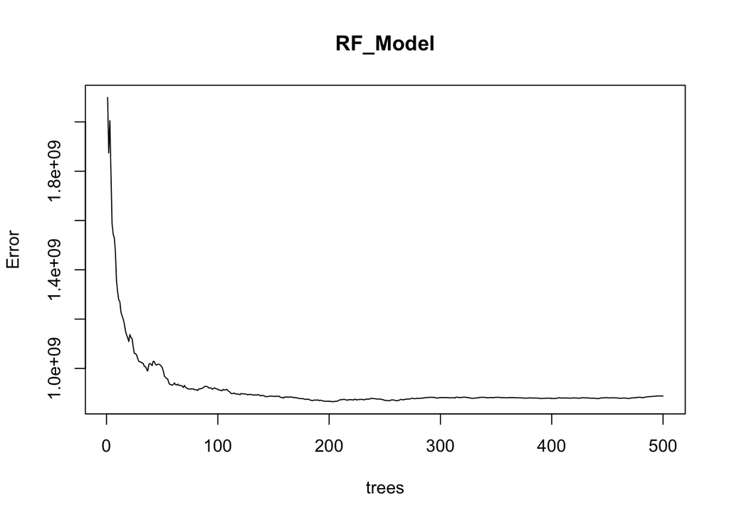

```r
# Plotting the Random Forest Model
plot(RF_Model)
```

### Random Forest Prediction and Results

```r
RF_Prediction <- predict(RF_Model, RF_HouseData_Test, type = "response")
cor(RF_Prediction,RF_HouseData_Test$SalePrice)
```

```
## [1] 0.9354778
```

```r
RMSE(RF_Prediction,RF_HouseData_Test$SalePrice)
```

```
## [1] 28663.01
```

There is a strong correlation of 0.935 between the house prices predicted by the Random Forest Model and actual prices. This implies a good prediction and that the predicted prices follow a similar trend with the real prices. Compared to the correlation achieved when when all the variables from the Boruta screening were used, the achieved correlation with this set of variables is higher by approximately 0.0006. The RMSE which is related to the predicted sum of error is 2.866300710^{4}.

## ANN Model

### Importing the required libraries

```r
library(nnet)
require(RCurl)
```

### Renaming Train and Test Data for Clarity

```r
ANN_HouseData_Train <- Norm_HouseData_Train
ANN_HouseData_Test <- Norm_HouseData_Test
```

### Creating the ANN Model

In creating the ANN Model, we experimented with the same 2 variable combinations as described above for the Random Forest Model. Again, the best accuracy was achieved using only the significant variables from the Stepwise Regression. Thus, our final ANN Model uses that combination of variables.

```r
set.seed(300)
ANN_Model <- nnet(SalePrice ~ Neighborhood + HouseStyle + MasVnrArea + FullBath + MSZoning + Exterior1st + BsmtFinType1 + X2ndFlrSF + BedroomAbvGr + TotRmsAbvGrd + Functional + LotFrontage + LandContour + LandSlope + Condition1 + YearBuilt + ExterQual + KitchenAbvGr + KitchenQual + Fireplaces + WoodDeckSF + SaleCondition + LotArea + LotShape + BldgType + OverallQual + OverallCond + BsmtQual + GrLivArea + BsmtFullBath + KitchenQual + + GarageCars + GarageQual + GarageCond,
    data=ANN_HouseData_Train,
    size=10, linout=TRUE, skip=TRUE, MaxNWts=10000, trace=FALSE, maxit=100)
```

### ANN Prediction and Results

```r
# ANN Prediction
ANN_Prediction <- predict(ANN_Model, newdata=ANN_HouseData_Test[,!names(ANN_HouseData_Test)=="SalePrice"])

# ANN Results
cor(ANN_Prediction, ANN_HouseData_Test$SalePrice)
```

```
##           [,1]
## [1,] 0.8761163
```

```r
RMSE(ANN_Prediction, ANN_HouseData_Test$SalePrice)
```

```
## [1] 39711.78
```

The ANN Model predictions and the actual house prices have a correlation of 0.876. This correlation is approximately 0.037 higher than the correlation obtained when all the variables from Boruta Screening were used. The RMSE is 3.971178210^{4}. The RMSE here is higher than what we got from the Random Forest Model.

## SVR Model

### Importing the required library

```r
library(kernlab)
```

### Renaming Train and Test Data for Clarity

```r
SVR_HouseData_Train <- OG_HouseData_Train
SVR_HouseData_Test <- OG_HouseData_Test
```

### Creating the SVR Model

To decide the final form of our Support Vector Regression Model, we went through a two-step experimentation process. First we used all the variables that passed the Boruta Screening and tested how the SVR Model performs with different kernels to find the optimal kernel for the model. The tested kernels were rbfdot, vanilladot, tanhdot and polydot. The highest correlation between predicted and actual house prices was achieved using the rbfdot kernel.

In the second step, we tested if it improves the accuracy to use only the significant variables from the Stepwise Regression with the rbfdot kernel and found out that it does not - the better accuracy is achieved by using all the variables that passed the Boruta Screening. The achieved correlation between the predicted and actual house prices was approximately 0.003 better for the model that uses all the variables that passed the Boruta Screening and, thus that combination of variables is used in our final SVR Model.

```r
# Constructing an SVR Model with all variables that passed the Boruta Screening
set.seed(300)
SVR_Model <- ksvm(SalePrice ~ ., data = SVR_HouseData_Train,
                          kernel = "rbfdot")
```

### SVR Model Prediction and Results

```r
# SVR Model Prediction
SVR_Prediction <- predict(SVR_Model, SVR_HouseData_Test)

# SVR Model Results
cor(SVR_Prediction, SVR_HouseData_Test$SalePrice)
```

```
##           [,1]
## [1,] 0.9360918
```

```r
RMSE(SVR_Prediction, SVR_HouseData_Test$SalePrice)
```

```
## [1] 28538.98
```

The house prices predicted by the SVR Model that uses all the variables that passed the Boruta Screening and the rbfdot kernel, and the actual house prices have a correlation of 0.936. The RMSE is 2.853897710^{4}. This is so far the model yielding the lowest error (RMSE) in our analysis.

## kNN Model

### Renaming Train and Test Data for Clarity

```r
kNN_HouseData_Train <- Norm_HouseData_Train
kNN_HouseData_Test <- Norm_HouseData_Test
```

### Creating the kNN Model

For the kNN Model, we once again tested the same 2 variable combinations. Using all the variables that passed the Boruta Training seemed to produce the better accuracy and, thus that variable combination is chosen for our final kNN Model. When all the variables that passed the Boruta Training were used, the achieved correlation between the predicted and actual house prices was approximately 0.0037 higher than when only the significant variables from the Stepwise Regression were used.

```r
# Training Control using a repeated 10-fold cross-validation to find the optimal k-value
trControl <- trainControl(method = 'repeatedcv',number = 10, repeats = 3)
```

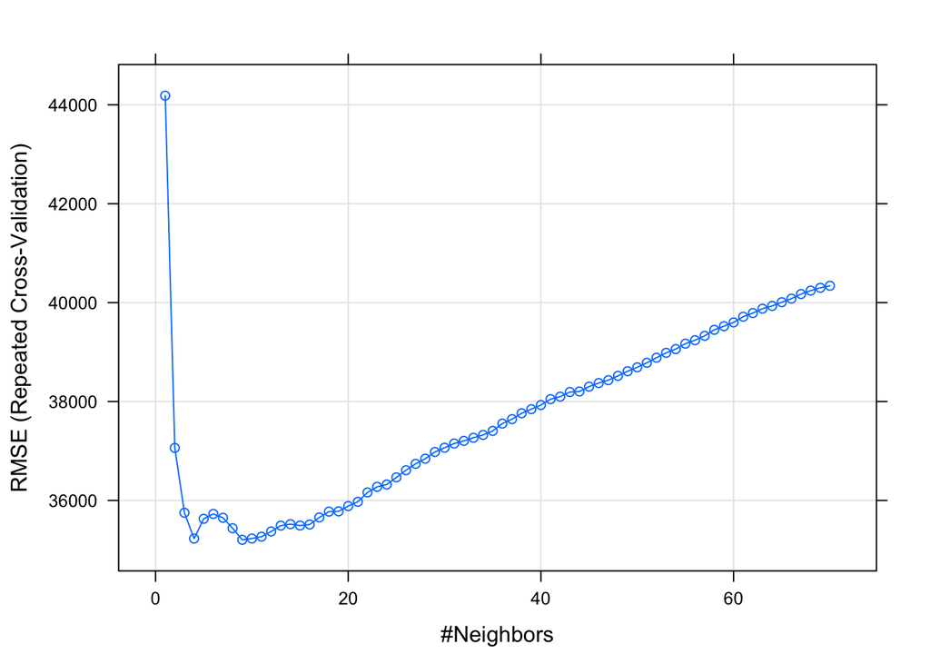

```r
# Creating the model
set.seed(300)
kNN_Model <- train(SalePrice ~ ., data = kNN_HouseData_Train, tuneGrid = expand.grid(k=1:70), method = 'knn', trControl = trControl, preProc = c('center', 'scale'))

# Plotting the kNN model
plot(kNN_Model)
```

```r
# Looking into the variable importance within the kNN Model
varImp(kNN_Model)
```

```
## loess r-squared variable importance
##
##   only 20 most important variables shown (out of 55)
##
##              Overall
## OverallQual   100.00
## GrLivArea      84.24
## TotalBsmtSF    74.37
## ExterQual      69.03
## GarageArea     67.27
## X1stFlrSF      63.97
## GarageCars     63.27
## BsmtQual       58.59
## KitchenQual    54.56
## FullBath       54.18
## TotRmsAbvGrd   47.46
## BsmtFinSF1     46.20
## YearBuilt      46.13
## X2ndFlrSF      43.57
## MasVnrArea     39.45
## YearRemodAdd   38.32
## Fireplaces     33.03
## GarageFinish   30.02
## GarageType     27.33
## Foundation     26.02
```

### kNN Model Prediction and Results

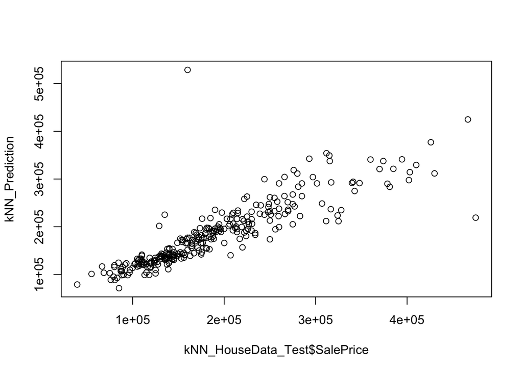

```r
kNN_Prediction <- predict(kNN_Model, newdata = kNN_HouseData_Test)
plot(kNN_Prediction ~ kNN_HouseData_Test$SalePrice)
```

```r
cor(kNN_Prediction, kNN_HouseData_Test$SalePrice)
```

```
## [1] 0.8630208
```

```r
RMSE(kNN_Prediction, kNN_HouseData_Test$SalePrice)
```

```
## [1] 40616.09
```

The plot above shows the actual sale price of a house against the predicted sale price of the house. Since the plot is pretty linear - with the exception of a few outliers - and has a slope close to one, the kNN Model seems to be a quite decent model in predicting the sale price of a house.

The kNN Model predictions and the actual house prices have a correlation of 0.863, which supports the indication of the plot that the kNN Model is a decent predictor for house prices. The RMSE is 4.061609410^{4}.

# 8. Combined Prediction Model

## Building a dataframe containing predictions of all models

```r
House_Prices <- data.frame(RF_Prediction,ANN_Prediction,SVR_Prediction,kNN_Prediction,OG_HouseData_Test$SalePrice)
colnames(House_Prices) <- c("Random Forest", "ANN", "SVR", "kNN", "True Price")
```

## Combined Model Prediction Models

We have built two combined models, one of which is weighted by correlation and another which is weighted by RMSE. The second combined model uses RMSEs of the individual models to conduct an inverse weighting scheme that yields the results, since a smaller RMSE means a better fit.

### Creating the Correlation-weighted Combined Model

```r
# Correlations
RF_Cor <- cor(House_Prices$`Random Forest`,House_Prices$`True Price`)
ANN_Cor <- cor(House_Prices$ANN,House_Prices$`True Price`)
SVR_Cor <- cor(House_Prices$SVR,House_Prices$`True Price`)
kNN_Cor <- cor(House_Prices$kNN,House_Prices$`True Price`)

# Sum of Correlations
SUM_Of_Cor <- RF_Cor + ANN_Cor + SVR_Cor + kNN_Cor

# Weights of models
RF_WeightCor <- RF_Cor / SUM_Of_Cor
ANN_WeightCor <- ANN_Cor / SUM_Of_Cor
SVR_WeightCor <- SVR_Cor / SUM_Of_Cor
kNN_WeightCor <- kNN_Cor / SUM_Of_Cor

# Taking the correlation-weighted average of predictions
House_Prices[,"Correlation Weighted Average"] <- House_Prices$`Random Forest` * RF_WeightCor + House_Prices$ANN * ANN_WeightCor + House_Prices$SVR * SVR_WeightCor + House_Prices$kNN * kNN_WeightCor
```

### Creating the RMSE-weighted Combined Model

```r
# RMSE for each model
RF_RMSE <- RMSE(House_Prices$`Random Forest`,House_Prices$`True Price`)
ANN_RMSE <- RMSE(House_Prices$ANN,House_Prices$`True Price`)
SVR_RMSE <- RMSE(House_Prices$SVR,House_Prices$`True Price`)
kNN_RMSE <- RMSE(House_Prices$kNN,House_Prices$`True Price`)

# Sum of RMSEs
SUM_Of_RMSE <- RF_RMSE + ANN_RMSE + SVR_RMSE + kNN_RMSE

# Weights of models
RF_WeightRMSE <- (1 - RF_RMSE / SUM_Of_RMSE)*(1/(4-1))
ANN_WeightRMSE <- (1 - ANN_RMSE / SUM_Of_RMSE)*(1/(4-1))
SVR_WeightRMSE <- (1 - SVR_RMSE / SUM_Of_RMSE)*(1/(4-1))
kNN_WeightRMSE <- (1 - kNN_RMSE / SUM_Of_RMSE)*(1/(4-1))

# Taking the RMSE-weighted average of predictions
House_Prices[,"RMSE Weighted Average"] = House_Prices$`Random Forest` * RF_WeightRMSE + House_Prices$ANN * ANN_WeightRMSE + House_Prices$SVR * SVR_WeightRMSE + House_Prices$kNN * kNN_WeightRMSE
```

## Combined Model Results

### Results of the Correlation-weighted Model

```r
correlationCombined_1 <- cor(House_Prices$`Correlation Weighted Average`, House_Prices$`True Price`)
rmseCombined_1 <- RMSE(House_Prices$`Correlation Weighted Average`,House_Prices$`True Price`)
```

The house prices predicted by our correlation-weighted combined model and the actual house prices have a correlation of 0.927. The RMSE for this model is 3.022083410^{4}.

### Results of the RMSE-weighted Model

```r
correlationCombined_2 <- cor(House_Prices$`RMSE Weighted Average`, House_Prices$`True Price`)
rmseCombined_2 <- RMSE(House_Prices$`RMSE Weighted Average`,House_Prices$`True Price`)
```

The house prices predicted by our combined model that uses the inverse RMSE weighting and the actual house prices have a correlation of 0.928. The RMSE for the model is 3.010927610^{4}.

# 9. Conclusion

Our objective was to predict Ames, Iowa property prices using machine learning models. As a base for our work we used an incredible Ames Housing Dataset.

Before creating our models, we did some data cleaning. Firstly, we handled all NAs in the dataset accordingly and used the Boruta Package to identify important variables in the dataset. Furthermore, we used linear and stepwise regressions to take a basic look on the significant variables effecting house prices.

Based on the cleaned data, we then went on and built four different predictive models, including a Random Forest Model, an Artificial Neural Network Model, a Support Vector Machine Model, and a k-Nearest-Neighbors Model. Out of the predictions of the four models, the predicted prices produced with the SVR Model had the highest correlation with the actual house prices listed in our Test Dataset. The correlation between the SVR Model Predictions and the actual house prices was 0.9361. Furthermore, the SVR also had the lowest RMSE among all models, 2.853897710^{4}.

The other models also performed fairly well. The Random Forest Model was the second most accurate. The correlation between the predictions made with the Random Forest Model and the actual house prices was 0.9355 Furthermore, the correlations between the predictions made by the ANN Model and the kNN Model and the actual house prices were 0.8761 and 0.863 respectively.

After creating the four individual models, we still thought that we could improve our predictions by obtaining a correlation-weighted average and also a RMSE inverse-weighted-average of the predictions of the individual models to create combined prediction models that would then be trained across multiple mechanisms. The correlations between the price predictions made with our correlation- and RMSE-weighted combined models and the actual house prices were 0.927 and 0.928 respectively, along with the RMSEs being 3.022083410^{4} and 3.010927610^{4}. These results still couldn’t outperform the individual SVR model in terms of neither prediction trends (correlation) nor errors (RMSE).

Finally, we use our best model, the SVR Model, to predict the prices for Ames, Iowa houses listed in a specific testing dataset provided in Kaggle (test.csv / rawHouseData_Test) and to create a submission file including the predictions. We will submit that file to the Kaggle Competition that is based on the Ames Housing Dataset.

## Constructing the Final Prediction for the Kaggle Competition

### Importing Test Data

```r
rawHouseData_Test <- read.csv("test.csv", stringsAsFactors = FALSE)
```

### Cleaning the Test Data

We have to clean the Test Data in a similar fashion than what we did with the Train Data in the beginning of the file.

#### Converting Data into Characters for Data Cleaning

```r
CharCategory <- c(names(Filter(is.character, rawHouseData_Test)), "MSSubClass")
```

#### Removing and Imputing NAs

```r
# Dropping the GarageYrBlt column, as NAs refer to garage not built, imputing NAs with year = 0 might affect regression and other garage variables exist. Since other garage variables exist, dropping this column has no significant effect.
rawHouseData_Test <- rawHouseData_Test[,!names(rawHouseData_Test)=="GarageYrBlt"]

# Imputing NAs in MasVnrArea with 0
rawHouseData_Test$MasVnrArea <- ifelse(is.na(rawHouseData_Test$MasVnrArea) == TRUE, 0, rawHouseData_Test$MasVnrArea)

# Imputing NAs by "Missing" for characters for the rest of the columns (i.e. e.g. PoolQC, MiscFeature, Alley), where NA means that attribute does not exist
for(i in CharCategory){
  rawHouseData_Test[,i] = ifelse(is.na(rawHouseData_Test[,i]), "Missing", rawHouseData_Test[,i])
}

# Imputing the NAs for Lot Frontage using predictive mean matching
rawHouseData_Test <- mice(rawHouseData_Test, m=5, maxit = 50, method = 'pmm', seed = 100)
rawHouseData_Test <- mice::complete(rawHouseData_Test)
```

#### Further Cleaning based on Boruta Training

```r
# Selecting only the features that passed the Boruta Screening for the Train Data
cleanHouseData_Test <- rawHouseData_Test[getSelectedAttributes(final.boruta, withTentative = F)]

# Converting characters back into factors
cleanHouseData_Test[sapply(cleanHouseData_Test,is.character)] <- lapply(cleanHouseData_Test[sapply(cleanHouseData_Test,is.character)], as.factor)

# Adding SalePrice back into the test data
cleanHouseData_Test$SalePrice <- rawHouseData_Test$SalePrice
```

#### Creating the Same Format for the Test Data that the Train Data has

```r
cleanHouseData_Test[] <- data.matrix(cleanHouseData_Test)
```

### Constructing the Final Prediction

```r
Final_Kaggle_Prediction <- predict(SVR_Model, cleanHouseData_Test)
```

### Creating the Submission File

```r
# Adding the necessary information
Kaggle_Submission <- as.data.frame(rawHouseData_Test$Id)
Kaggle_Submission$SalePrice <- Final_Kaggle_Prediction

# Naming the Columns for the Submission File
colnames(Kaggle_Submission) <- c("Id","SalePrice")

# Writing the Submission File
write.csv(Kaggle_Submission, file = "Ames_House_Prices.csv", row.names = FALSE)
```